# Evaluation 3: get more numbers

Simulation evaluation

Janne Pott

13.04.2022

# Introduction

In our paper, we propose an upper bound for sets that are phylogenetic decisive (satisfying the 4-way partition property, 4WPP), but are not fixing taxon traceable. We give an example on how to construct such sets for any n by induction. The bound is given as

$$\binom{n}{4} - 3*n + 13$$

Here, I want to check not if we had one of those sets in our simulation, but how many such sets were created during the simulation. E.g., for $n=8$, the bound is $\binom{8}{4} - 3*8 + 13 = 70 - 24 + 13 = 59$. In our simulation, all sets with $k_{8}=59$ were correctly identified, either as decisive **and** fixing taxon traceable (FTT), or as not decisive **and** not FTT. However, there could be sets starting at $k_{start}<59$, that could be filled with some quadruples by fixing taxons, but not all quadruples. So at the end of the algorithm, there are $k_{start}+x$ quadruples input or resolved, but still not all. The question is, how many end at our bound?

```r
rm(list = ls())
time0<-Sys.time()

source("../SourceFile.R")
```

# Load data

```r
load("../results/02_SimulationResults_n06.RData")
load("../results/02_SimulationResults_n07.RData")
load("../results/02_SimulationResults_n08.RData")
load("../results/02_SimulationResults_n09.RData")
load("../results/02_SimulationResults_n10.RData")

SimulationResults_n06[,n := 6]
SimulationResults_n07[,n := 7]
SimulationResults_n08[,n := 8]
SimulationResults_n09[,n := 9]
SimulationResults_n10[,n := 10]

sim = rbind(SimulationResults_n06,SimulationResults_n07,SimulationResults_n08,SimulationResults_n09,SimulationResults_n10)
Sim = copy(sim)
Sim = Sim[NR_PhyloDec>0,]
Sim[,sum(NR_PhyloDec)]
```

```
#> [1] 1740621
```

```r
Sim[,sum(NR_PhyloDec)] - Sim[,sum(NR_FTT)]
```

```
#> [1] 19588
```

```r
dumTab = foreach(i=1:dim(Sim)[1])%do%{
  #i=1
  myRow = Sim[i,]
  myk = myRow$k
  myn = myRow$n

  if(myn<10){
      filefn = paste0("../results/02_SimulationsData_n0",myn,"/SimulationResults_n",myn,"_k",myk,"_rep10000.RData")
  }else{
      filefn = paste0("../results/02_SimulationsData_n",myn,"/SimulationResults_n",myn,"_k",myk,"_rep10000.RData")
  }
  load(filefn)
  myTest = myTest[FWPP == "PhyloDec",]
  res = data.table(n=myn,
                   k=myk,
                   FWPP = T,
                   FixingTaxa = F,
                   input = myTest$input)
  filt = myTest$FTT =="FTT"
  res[filt,FixingTaxa:=T]
  res = res[!filt,]
  res
}

PhyloDecSets_notFTT = rbindlist(dumTab)
PhyloDecSets_notFTT[,table(n)]
```

```
#> n
#>    6    7    8    9   10
#>  492 3044 4809 5801 5442
```

Okay, there are 1,740,621 phylogenetic decisive sets, of which only 19,588 ar **not** also fixing taxon traceable. THis is a bit more than 1%.

# Test data

These 19,588 sets I want to test again. I know they are not FTT, but I want to know how many resolved quraduples can be added to the input quadruples, hence getting the $k_{end}$.

```r
y = seq(from=1,to=dim(PhyloDecSets_notFTT)[1],by=500)

registerDoMC(cores=20)

test = foreach(i=1:dim(PhyloDecSets_notFTT)[1])%dopar%{
#test = foreach(i=1:500)%dopar%{
  #i=1
  if(i %in% y)message("Working on i=",i)
  myRow = PhyloDecSets_notFTT[i,]
  myRow[,NR := i]
  myInput = myRow$input
  myInput = unlist(strsplit(myInput,split = "[|]"))
  myOutput = data.table(myInput = myInput)

  myFn = paste0("../results/03_Simulation_checkBound/Example_NR",i,"_n",myRow$n,"_k",myRow$k,".txt")

  if(file.exists(myFn)==F) fwrite(myOutput,file=myFn,col.names = F)
  TestData = FTT_createInput(fn = myFn, sepSym = "_",c = 4)
  TestFTT = FTT_algorithmRed(data=TestData$data,verbose = F,c = 4,n = myRow$n)
  stopifnot(sum(TestFTT$status=="input") == myRow$k)

  myRow[,n_resolved :=sum(TestFTT$status=="resolved") ]
  myRow[,n_unResolved :=sum(TestFTT$status=="unresolved") ]
  myRow[,n_green := k + n_resolved]

  solvedTaxa = c(TestFTT[status != "unresolved",taxa1],
                 TestFTT[status != "unresolved",taxa2],
                 TestFTT[status != "unresolved",taxa3],
                 TestFTT[status != "unresolved",taxa4])
  inputTaxa = c(TestFTT[status == "input",taxa1],
                 TestFTT[status == "input",taxa2],
                 TestFTT[status == "input",taxa3],
                 TestFTT[status == "input",taxa4])

  x1 = table(solvedTaxa)
  x2 = as.numeric(x1)
  x3 = paste(x2,collapse = "|")
  x4 = x2[order(x2)]
  x5 = paste(x4,collapse = "|")

  x1 = table(inputTaxa)
  x2 = as.numeric(x1)
  x7 = paste(x2,collapse = "|")
  x4 = x2[order(x2)]
  x9 = paste(x4,collapse = "|")

  myRow[,solvedTaxa := x3]
  myRow[,solvedTaxa_ordered := x5]
  myRow[,inputTaxa := x7]
  myRow[,inputTaxa_ordered := x9]
  myRow
}

PhyloDecSets_notFTT = rbindlist(test)
save(PhyloDecSets_notFTT,file = "../results/03_Simulation_checkForPattern.RData")
```

# Check for patterns

I only want this for the maximal $k_{end}$, and I want to know how many times this happens.

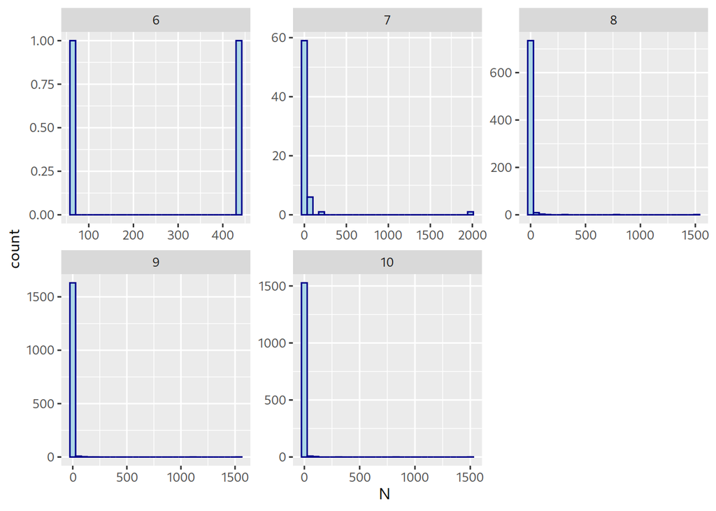

```r
load("../results/03_Simulation_checkForPattern.RData")

dummy = PhyloDecSets_notFTT[,.N,by=c("solvedTaxa_ordered","n")]
plot = ggplot(dummy, aes(x=N))+
  facet_wrap(~n, scales = "free")+
  geom_histogram(color="darkblue", fill="lightblue")
plot
```

```r
dumTab = foreach(i = 6:10)%do%{
  #i=9
  myTab = copy(PhyloDecSets_notFTT)
  myTab = myTab[n==i,]

  dummy2 = myTab[,.N,solvedTaxa_ordered]
  dummy2[,relN := N/dim(myTab)[1]]
  dummy2 = dummy2[relN>=0.1]
  print(dummy2)
  setorder(dummy2,-N)

  dumTab2 = foreach(j = 1:dim(dummy2)[1])%do%{
    #j=1
    myTab2 = copy(myTab)
    myTab2 = myTab2[solvedTaxa_ordered == dummy2[j,solvedTaxa_ordered],]

    res = data.table(n=i,
                   PosQuadruples = choose(i,4),
                   PosNRTaxa = choose(i-1,3),
                   green = max(myTab2$n_green),
                   red = choose(i,4) - max(myTab2$n_green),
                   MinNRTaxa = choose(i-1,3) - choose(i,4) + max(myTab2$n_green),
                   patternCount =myTab2[n_green == max(n_green),table(solvedTaxa_ordered)[1]],
                   relCount = dummy2[j,relN],
                   minK = myTab2[,min(k)],
                   maxK = myTab2[,max(k)],
                   taxa = myTab2[n_green == max(n_green),unique(solvedTaxa_ordered)])
    res
  }
  dumTab2 = rbindlist(dumTab2)

  dumTab2
}
```

```
#>    solvedTaxa_ordered   N      relN
#> 1:        5|7|7|7|7|7 432 0.8780488
#> 2:        6|6|6|6|6|6  60 0.1219512
#>      solvedTaxa_ordered    N      relN
#> 1: 12|15|15|16|16|17|17 1979 0.6501314
#>         solvedTaxa_ordered    N      relN
#> 1: 24|28|28|30|30|32|32|32 1514 0.3148264
#> 2: 23|27|29|29|31|31|31|31  804 0.1671865
#>            solvedTaxa_ordered    N      relN
#> 1: 40|45|48|49|51|51|52|52|52 1100 0.1896225
#> 2: 42|47|47|50|50|53|53|53|53 1537 0.2649543
#>               solvedTaxa_ordered    N      relN
#> 1: 67|73|73|77|77|81|81|81|81|81 1503 0.2761852
#> 2: 64|70|74|76|78|78|80|80|80|80  832 0.1528850
```

```r
FinalResult = rbindlist(dumTab)
FinalResult
```

```
#>     n PosQuadruples PosNRTaxa green red MinNRTaxa patternCount  relCount minK
#> 1:  6            15        10    10   5         5          432 0.8780488    9
#> 2:  6            15        10     9   6         4           60 0.1219512    9
#> 3:  7            35        20    27   8        12         1979 0.6501314   19
#> 4:  8            70        35    59  11        24         1514 0.3148264   34
#> 5:  8            70        35    58  12        23          804 0.1671865   34
#> 6:  9           126        56   112  14        42         1537 0.2649543   55
#> 7:  9           126        56   110  16        40         1100 0.1896225   55
#> 8: 10           210        84   193  17        67         1503 0.2761852   84
#> 9: 10           210        84   190  20        64          832 0.1528850   84
#>    maxK                          taxa
#> 1:   10                   5|7|7|7|7|7
#> 2:    9                   6|6|6|6|6|6
#> 3:   26          12|15|15|16|16|17|17
#> 4:   50       24|28|28|30|30|32|32|32
#> 5:   50       23|27|29|29|31|31|31|31
#> 6:   89    42|47|47|50|50|53|53|53|53
#> 7:   84    40|45|48|49|51|51|52|52|52
#> 8:  146 67|73|73|77|77|81|81|81|81|81
#> 9:  132 64|70|74|76|78|78|80|80|80|80
```

```r
save(FinalResult,file = "../results/03_FinalResult.RData")
```

```r
message("\nTOTAL TIME : " ,round(difftime(Sys.time(),time0,units = "mins"),3)," minutes")
```

```
#>
#> TOTAL TIME : 123.985 minutes
```